# Application Processing Efficiency Analysis

### Trello Actions data

Import actions and convert the action date to POSIX format so it can be processed.

```r
dog.actions <- read.csv("./Data/dog_actions.csv", stringsAsFactors = FALSE)
dog.actions$date <- as.POSIXlt(dog.actions$date, format="%Y-%m-%dT%H:%M:%SZ")

cat.actions <- read.csv("./Data/cat_actions.csv", stringsAsFactors = FALSE)
cat.actions$date <- as.POSIXlt(cat.actions$date, format="%Y-%m-%dT%H:%M:%SZ")
```

Using the timestamp, we now identify the last recorded checklist activity, and only keep that instance when combining data with the larger dataset.

```r
dog.actions <- dog.actions[order(dog.actions$data.card.id, dog.actions$date, decreasing = TRUE),]
dog.actions <- dog.actions[which(!duplicated(dog.actions$data.card.id)),]
dog.appsandcards <- merge(dog.appsandcards, dog.actions, by.x="outcome_trello_id", by.y="data.card.id", all.x=TRUE, all.y=FALSE)

cat.actions <- cat.actions[order(cat.actions$data.card.id, cat.actions$date, decreasing = TRUE),]
cat.actions <- cat.actions[which(!duplicated(cat.actions$data.card.id)),]
cat.appsandcards <- merge(cat.appsandcards, cat.actions, by.x="outcome_trello_id", by.y="data.card.id", all.x=TRUE, all.y=FALSE)
```

```r
dog.appsandcards$decision.status <- "no decision"
dog.appsandcards$decision.status[which(grepl(paste(c("denied",
                                            "do not follow up",
                                            "adopted",
                                            "adoption follow up",
                                            "approved",
                                            "ready to adopt",
                                            "ready for review",
                                            "reviewed with handouts only",
                                            "approved with limitation",
                                            "dog meet",
                                            "returned",
                                            "adopted elsewhere"), collapse="|"), dog.appsandcards$label_names))] <- "decision"

dog.appsandcards$date <- as.character(dog.appsandcards$date)
dog.appsandcards$date <- ifelse(dog.appsandcards$decision.status == "no decision", "2018-12-31 23:59:59", dog.appsandcards$date)
dog.appsandcards$date <- as.POSIXlt(dog.appsandcards$date)
dog.appsandcards$date_submitted <- as.POSIXlt(dog.appsandcards$date_submitted, format="%m/%d/%Y")
dog.appsandcards$processing.time <- as.numeric(difftime(dog.appsandcards$date, dog.appsandcards$date_submitted, units="days"))

# mark decision vs no decision
cat.appsandcards$decision.status <- "no decision"
cat.appsandcards$decision.status[which(grepl(paste(c("denied",
                                            "do not follow up",
                                            "adopted",
                                            "adoption follow up",
                                            "approved",
                                            "ready to adopt",
                                            "ready for review",
                                            "reviewed with handouts only",
                                            "approved with limitation",
                                            "cat meet",
                                            "returned",
                                            "adopted elsewhere"), collapse="|"), cat.appsandcards$label_names))] <- "decision"

cat.appsandcards$date <- as.character(cat.appsandcards$date)
cat.appsandcards$date <- ifelse(cat.appsandcards$decision.status == "no decision", "2018-12-31 23:59:59", cat.appsandcards$date)
cat.appsandcards$date <- as.POSIXlt(cat.appsandcards$date)
cat.appsandcards$date_submitted <- as.POSIXlt(cat.appsandcards$date_submitted, format="%m/%d/%Y")


cat.appsandcards$processing.time <- as.numeric(difftime(cat.appsandcards$date, cat.appsandcards$date_submitted, units="days"))
```

```r
summary(dog.appsandcards$processing.time)
```

```
##    Min. 1st Qu.  Median    Mean 3rd Qu.    Max.
## -41.267   2.809   6.757  23.739  20.500 123.042
```

```r
summary(cat.appsandcards$processing.time)
```

```
##     Min.  1st Qu.   Median     Mean  3rd Qu.     Max.     NA's
## -194.330    2.673    5.905   21.431   27.884  122.042        4
```

For both dogs and cats there are some applications where the submission date seems to be after the latest action (which doesn’t make sense). Specifically, 1 instance was found for dogs, and 10 instances were found for cats. We’ll remove them.

```r
dog.appsandcards <- dog.appsandcards[which(dog.appsandcards$processing.time >0),]
cat.appsandcards <- cat.appsandcards[which(cat.appsandcards$processing.time >0),]
```

```r
dog.appsandcards <- dog.appsandcards[which(dog.appsandcards$decision.status == "decision" |
                                            (dog.appsandcards$decision.status == "no decision" & dog.appsandcards$processing.time > 10)),]
cat.appsandcards <- cat.appsandcards[which(cat.appsandcards$decision.status == "decision" |
                                            (cat.appsandcards$decision.status == "no decision" & cat.appsandcards$processing.time > 10)),]
dog.appsandcards$efficient <- ifelse(dog.appsandcards$processing.time>10,0,1)
cat.appsandcards$efficient <- ifelse(cat.appsandcards$processing.time>10,0,1)
```

### Census data

Next we’ll import census data. The following datasets were extracted:

#### Education

```r
educ <- read.csv("/home/karla/Documents/RLadies/joys_fork/2019_datathon/Analyses/3_GIS/KF_CensusData/ACS_17_5YR_S1401_with_ann.csv",
                 stringsAsFactors = FALSE)
educ.descr <- read.csv("/home/karla/Documents/RLadies/joys_fork/2019_datathon/Analyses/3_GIS/KF_CensusData/ACS_17_5YR_S1401_metadata.csv",
                 stringsAsFactors = FALSE, header = FALSE)
select.vars <- c("GEO.id2",
                "HC02_EST_VC01",
                "HC02_EST_VC02",
                "HC02_EST_VC03",
                "HC02_EST_VC04",
                "HC02_EST_VC05",
                "HC02_EST_VC06",
                "HC02_EST_VC07",
                "HC02_EST_VC08",
                "HC02_EST_VC09",
                "HC02_EST_VC11",
                "HC02_EST_VC15",
                "HC02_EST_VC16",
                "HC02_EST_VC18",
                "HC02_EST_VC19",
                "HC02_EST_VC21",
                "HC02_EST_VC22",
                "HC02_EST_VC24",
                "HC02_EST_VC25",
                "HC02_EST_VC27",
                "HC02_EST_VC28",
                "HC02_EST_VC30",
                "HC02_EST_VC31",
                "HC02_EST_VC33",
                "HC02_EST_VC34",
                "HC02_EST_VC36",
                "HC02_EST_VC37",
                "HC02_EST_VC39",
                "HC02_EST_VC40")
select.vars.df.educ <- data.frame(select.vars = paste0(select.vars,"_educ"),
                             descr = educ.descr$V2[which(educ.descr$V1 %in% select.vars)])
knitr::kable(select.vars.df.educ)
```

| select.vars | descr |
| --- | --- |
| GEO.id2_educ | Id2 |
| HC02_EST_VC01_educ | Percent; Estimate; Population 3 years and over enrolled in school |
| HC02_EST_VC02_educ | Percent; Estimate; Nursery school, preschool |
| HC02_EST_VC03_educ | Percent; Estimate; Kindergarten to 12th grade |
| HC02_EST_VC04_educ | Percent; Estimate; Kindergarten |
| HC02_EST_VC05_educ | Percent; Estimate; Elementary: grade 1 to grade 4 |
| HC02_EST_VC06_educ | Percent; Estimate; Elementary: grade 5 to grade 8 |
| HC02_EST_VC07_educ | Percent; Estimate; High school: grade 9 to grade 12 |
| HC02_EST_VC08_educ | Percent; Estimate; College, undergraduate |
| HC02_EST_VC09_educ | Percent; Estimate; Graduate, professional school |
| HC02_EST_VC11_educ | Percent; Estimate; Population enrolled in college or graduate school |
| HC02_EST_VC15_educ | Percent; Estimate; Population 3 to 4 years |
| HC02_EST_VC16_educ | Percent; Estimate; Population 3 to 4 years - 3 to 4 year olds enrolled in school |
| HC02_EST_VC18_educ | Percent; Estimate; Population 5 to 9 years |
| HC02_EST_VC19_educ | Percent; Estimate; Population 5 to 9 years - 5 to 9 year olds enrolled in school |
| HC02_EST_VC21_educ | Percent; Estimate; Population 10 to 14 years |
| HC02_EST_VC22_educ | Percent; Estimate; Population 10 to 14 years - 10 to 14 year olds enrolled in school |
| HC02_EST_VC24_educ | Percent; Estimate; Population 15 to 17 |
| HC02_EST_VC25_educ | Percent; Estimate; Population 15 to 17 - 15 to 17 year olds enrolled in school |
| HC02_EST_VC27_educ | Percent; Estimate; Population 18 to 19 years |
| HC02_EST_VC28_educ | Percent; Estimate; Population 18 to 19 years - 18 and 19 year olds enrolled in school |
| HC02_EST_VC30_educ | Percent; Estimate; Population 20 to 24 years |
| HC02_EST_VC31_educ | Percent; Estimate; Population 20 to 24 years - 20 to 24 year olds enrolled in school |
| HC02_EST_VC33_educ | Percent; Estimate; Population 25 to 34 years |
| HC02_EST_VC34_educ | Percent; Estimate; Population 25 to 34 years - 25 to 34 year olds enrolled in school |
| HC02_EST_VC36_educ | Percent; Estimate; Population 35 years and over |
| HC02_EST_VC37_educ | Percent; Estimate; Population 35 years and over - 35 years and over enrolled in school |
| HC02_EST_VC39_educ | Percent; Estimate; Population 18 to 24 years |
| HC02_EST_VC40_educ | Percent; Estimate; Population 18 to 24 years - Enrolled in college or graduate school |

```r
educ <- educ[,select.vars]
educ <- educ[2:nrow(educ),]   # first row is an annotation
educ[educ=="(X)"] <- NA    # for some reason NA's are marked as '(X)' so we'll replace those with actual NAs
educ <- mutate_all(educ, function(x) as.numeric(as.character(x)))    # convert everything to numeric
educ <- select_if(educ, not_all_na)                        # eliminate columns that have all NAs
colnames(educ) <- paste0(colnames(educ),"_educ")           # attach a suffix to all columns to make them identifiable after combining with other sets
```

#### Median rent

```r
rent <- read.csv("/home/karla/Documents/RLadies/joys_fork/2019_datathon/Analyses/3_GIS/KF_CensusData/ACS_17_5YR_B25058_with_ann.csv",
                 stringsAsFactors = FALSE)
rent.descr <- read.csv("/home/karla/Documents/RLadies/joys_fork/2019_datathon/Analyses/3_GIS/KF_CensusData/ACS_17_5YR_B25058_metadata.csv",
                 stringsAsFactors = FALSE, header = FALSE)
select.vars <- c("GEO.id2",
                 "HD01_VD01")
select.vars.df.rent <- data.frame(select.vars = paste0(select.vars,"_rent"),
                             descr = rent.descr$V2[which(rent.descr$V1 %in% select.vars)])
knitr::kable(select.vars.df.rent)
```

| select.vars | descr |
| --- | --- |
| GEO.id2_rent | Id2 |
| HD01_VD01_rent | Estimate; Median contract rent |

```r
rent <- rent[,select.vars]
rent <- rent[2:nrow(rent),]   # first row is an annotation
rent[rent=="(X)"] <- NA    # for some reason NA's are marked as '(X)' so we'll replace those with actual NAs
rent <- mutate_all(rent, function(x) as.numeric(as.character(x)))    # convert everything to numeric
rent <- select_if(rent, not_all_na)                        # eliminate columns that have all NAs
colnames(rent) <- paste0(colnames(rent),"_rent")           # attach a suffix to all columns to make them identifiable after combining with other sets

census <- merge(educ, rent, by.x="GEO.id2_educ", by.y="GEO.id2_rent", all=TRUE)    # merge education and rent datasets
```

#### Computer and networking characteristics

```r
comp <- read.csv("/home/karla/Documents/RLadies/joys_fork/2019_datathon/Analyses/3_GIS/KF_CensusData/ACS_17_5YR_S2801_with_ann.csv",
                 stringsAsFactors = FALSE)   # computing devices
comp.descr <- read.csv("/home/karla/Documents/RLadies/joys_fork/2019_datathon/Analyses/3_GIS/KF_CensusData/ACS_17_5YR_S2801_metadata.csv",
                 stringsAsFactors = FALSE, header = FALSE)
select.vars <- c("GEO.id2",
                "HC02_EST_VC04",
                "HC02_EST_VC05",
                "HC02_EST_VC06",
                "HC02_EST_VC07",
                "HC02_EST_VC08",
                "HC02_EST_VC09",
                "HC02_EST_VC10",
                "HC02_EST_VC11",
                "HC02_EST_VC12",
                "HC02_EST_VC13",
                "HC02_EST_VC16",
                "HC02_EST_VC17",
                "HC02_EST_VC18",
                "HC02_EST_VC19",
                "HC02_EST_VC20",
                "HC02_EST_VC21",
                "HC02_EST_VC22",
                "HC02_EST_VC23",
                "HC02_EST_VC26",
                "HC02_EST_VC27",
                "HC02_EST_VC28",
                "HC02_EST_VC29",
                "HC02_EST_VC30",
                "HC02_EST_VC31",
                "HC02_EST_VC32",
                "HC02_EST_VC33",
                "HC02_EST_VC34",
                "HC02_EST_VC35",
                "HC02_EST_VC36",
                "HC02_EST_VC37")
select.vars.df.comp <- data.frame(select.vars = paste0(select.vars,"_comp"),
                             descr = comp.descr$V2[which(comp.descr$V1 %in% select.vars)])
knitr::kable(select.vars.df.comp)
```

| select.vars | descr |
| --- | --- |
| GEO.id2_comp | Id2 |
| HC02_EST_VC04_comp | Percent; Estimate; TYPES OF COMPUTER - Has one or more types of computing devices: |
| HC02_EST_VC05_comp | Percent; Estimate; TYPES OF COMPUTER - Has one or more types of computing devices: - Desktop or laptop |
| HC02_EST_VC06_comp | Percent; Estimate; TYPES OF COMPUTER - Has one or more types of computing devices: - Desktop or laptop - Desktop or laptop with no other type of computing device |
| HC02_EST_VC07_comp | Percent; Estimate; TYPES OF COMPUTER - Has one or more types of computing devices: - Smartphone |
| HC02_EST_VC08_comp | Percent; Estimate; TYPES OF COMPUTER - Has one or more types of computing devices: - Smartphone - Smartphone with no other type of computing device |
| HC02_EST_VC09_comp | Percent; Estimate; TYPES OF COMPUTER - Has one or more types of computing devices: - Tablet or other portable wireless computer |
| HC02_EST_VC10_comp | Percent; Estimate; TYPES OF COMPUTER - Has one or more types of computing devices: - Tablet or other portable wireless computer - Tablet or other portable wireless computer with no other type of compu… |
| HC02_EST_VC11_comp | Percent; Estimate; TYPES OF COMPUTER - Has one or more types of computing devices: - Other computer |
| HC02_EST_VC12_comp | Percent; Estimate; TYPES OF COMPUTER - Has one or more types of computing devices: - Other computer - Other computer with no other type of computing device |
| HC02_EST_VC13_comp | Percent; Estimate; TYPES OF COMPUTER - No computer |
| HC02_EST_VC16_comp | Percent; Estimate; TYPE OF INTERNET SUBSCRIPTIONS - With an Internet subscription: |
| HC02_EST_VC17_comp | Percent; Estimate; TYPE OF INTERNET SUBSCRIPTIONS - With an Internet subscription: - Dial-up with no other type of Internet subscription |
| HC02_EST_VC18_comp | Percent; Estimate; TYPE OF INTERNET SUBSCRIPTIONS - With an Internet subscription: - Broadband of any type |
| HC02_EST_VC19_comp | Percent; Estimate; TYPE OF INTERNET SUBSCRIPTIONS - With an Internet subscription: - Broadband of any type - Cellular data plan |
| HC02_EST_VC20_comp | Percent; Estimate; TYPE OF INTERNET SUBSCRIPTIONS - With an Internet subscription: - Broadband of any type - Cellular data plan - Cellular data plan with no other type of Internet subscription |
| HC02_EST_VC21_comp | Percent; Estimate; TYPE OF INTERNET SUBSCRIPTIONS - With an Internet subscription: - Broadband of any type - Broadband such as cable, fiber optic or DSL |
| HC02_EST_VC22_comp | Percent; Estimate; TYPE OF INTERNET SUBSCRIPTIONS - With an Internet subscription: - Broadband of any type - Satellite Internet service |
| HC02_EST_VC23_comp | Percent; Estimate; TYPE OF INTERNET SUBSCRIPTIONS - Without an Internet subscription |
| HC02_EST_VC26_comp | Percent; Estimate; HOUSEHOLD INCOME IN THE PAST 12 MONTHS (IN 2017 INFLATION-ADJUSTED DOLLARS) - Less than $20,000: |
| HC02_EST_VC27_comp | Percent; Estimate; HOUSEHOLD INCOME IN THE PAST 12 MONTHS (IN 2017 INFLATION-ADJUSTED DOLLARS) - Less than $20,000: - With dial-up Internet subscription alone |
| HC02_EST_VC28_comp | Percent; Estimate; HOUSEHOLD INCOME IN THE PAST 12 MONTHS (IN 2017 INFLATION-ADJUSTED DOLLARS) - Less than $20,000: - With a broadband Internet subscription |
| HC02_EST_VC29_comp | Percent; Estimate; HOUSEHOLD INCOME IN THE PAST 12 MONTHS (IN 2017 INFLATION-ADJUSTED DOLLARS) - Less than $20,000: - Without an Internet subscription |
| HC02_EST_VC30_comp | Percent; Estimate; HOUSEHOLD INCOME IN THE PAST 12 MONTHS (IN 2017 INFLATION-ADJUSTED DOLLARS) - $20,000 to $74,999: |
| HC02_EST_VC31_comp | Percent; Estimate; HOUSEHOLD INCOME IN THE PAST 12 MONTHS (IN 2017 INFLATION-ADJUSTED DOLLARS) - $20,000 to $74,999: - With dial-up Internet subscription alone |
| HC02_EST_VC32_comp | Percent; Estimate; HOUSEHOLD INCOME IN THE PAST 12 MONTHS (IN 2017 INFLATION-ADJUSTED DOLLARS) - $20,000 to $74,999: - With a broadband Internet subscription |
| HC02_EST_VC33_comp | Percent; Estimate; HOUSEHOLD INCOME IN THE PAST 12 MONTHS (IN 2017 INFLATION-ADJUSTED DOLLARS) - $20,000 to $74,999: - Without an Internet subscription |
| HC02_EST_VC34_comp | Percent; Estimate; HOUSEHOLD INCOME IN THE PAST 12 MONTHS (IN 2017 INFLATION-ADJUSTED DOLLARS) - $75,000 or more: |
| HC02_EST_VC35_comp | Percent; Estimate; HOUSEHOLD INCOME IN THE PAST 12 MONTHS (IN 2017 INFLATION-ADJUSTED DOLLARS) - $75,000 or more: - With dial-up Internet subscription alone |
| HC02_EST_VC36_comp | Percent; Estimate; HOUSEHOLD INCOME IN THE PAST 12 MONTHS (IN 2017 INFLATION-ADJUSTED DOLLARS) - $75,000 or more: - With a broadband Internet subscription |
| HC02_EST_VC37_comp | Percent; Estimate; HOUSEHOLD INCOME IN THE PAST 12 MONTHS (IN 2017 INFLATION-ADJUSTED DOLLARS) - $75,000 or more: - Without an Internet subscription |

```r
comp <- comp[,select.vars]
comp <- comp[2:nrow(comp),]   # first row is an annotation
comp[comp=="(X)"] <- NA    # for some reason NA's are marked as '(X)' so we'll replace those with actual NAs
comp <- mutate_all(comp, function(x) as.numeric(as.character(x)))    # convert everything to numeric
comp <- select_if(comp, not_all_na)                        # eliminate columns that have all NAs
colnames(comp) <- paste0(colnames(comp),"_comp")           # attach a suffix to all columns to make them identifiable after combining with other sets

census <- merge(educ, comp, by.x="GEO.id2_educ", by.y="GEO.id2_comp", all=TRUE)    # merge education and comp datasets
census.descr <- rbind(select.vars.df.educ,
                      select.vars.df.rent,
                      select.vars.df.comp)
```

## Analyses

We’re going to run analyses separately for dogs and cats. The process will be to first reduce the number of predictors, and then use the selected predictors to assess significance and contribution.

### Dogs

```r
appsandcards <- dog.appsandcards[,c("GEOID","efficient")]

all.geo <- appsandcards %>%
  group_by(GEOID) %>%
  summarise(efficient = sum(efficient)/n())

all.geo <- merge(all.geo,
                 census,
                 by.x="GEOID",
                 by.y="GEO.id2_educ",
                 all.x=TRUE)
all.geo <- all.geo[complete.cases(all.geo),]

# using lasso to extract variables

x <- model.matrix(efficient ~., data = all.geo)
x <- x[,-1]
cvfit <- cv.glmnet(x, all.geo$efficient, type.measure = 'mse', nfolds=5, alpha=.5)
c <- coef(cvfit, s='lambda.min', exact=TRUE)
inds <- which(c!=0)
vars <- data.frame(var = row.names(c)[inds],
                   value = c[inds])
vars <- vars[which(!vars$var %in% c("(Intercept)","GEOID")),]
vars <- vars[order(abs(vars$value), decreasing = TRUE),]

knitr::kable(census.descr[which(census.descr$select.vars %in% vars$var),])
```

|  | select.vars | descr |
| --- | --- | --- |
| 4 | HC02_EST_VC03_educ | Percent; Estimate; Kindergarten to 12th grade |
| 25 | HC02_EST_VC34_educ | Percent; Estimate; Population 25 to 34 years - 25 to 34 year olds enrolled in school |
| 37 | HC02_EST_VC08_comp | Percent; Estimate; TYPES OF COMPUTER - Has one or more types of computing devices: - Smartphone - Smartphone with no other type of computing device |
| 47 | HC02_EST_VC20_comp | Percent; Estimate; TYPE OF INTERNET SUBSCRIPTIONS - With an Internet subscription: - Broadband of any type - Cellular data plan - Cellular data plan with no other type of Internet subscription |
| 48 | HC02_EST_VC21_comp | Percent; Estimate; TYPE OF INTERNET SUBSCRIPTIONS - With an Internet subscription: - Broadband of any type - Broadband such as cable, fiber optic or DSL |

Now we combine with geographic data and reduce the set to include only Philadelphia county. We also calculate distance to the nearest PAWS location.

```r
all.geo.spatial <-
  sp::merge(x = pa_nj, y = all.geo, by = "GEOID", all.x=FALSE, all.y=TRUE)
all.geo.spatial <- all.geo.spatial[all.geo.spatial$COUNTYFP=="101",]

# calculate distance to nearest PAWS location

# PAWS Adoption locations taken from their website, and latlong obtained via https://gps-coordinates.org/
# PAC lat = 39.952030; Long = -75.143410
# NE lat =  40.084923, long = -75.036904
# Kawaii kitty Cafe Lat = 39.93867, long = -75.1496
# Petsmart Oregon Ave Lat = 39.917239, Lon = -75.187238
# Petsmart Broad & Washington Lat = 39.937967, Lon = -75.167576
# Grays Ferry Lat = 39.938748 Lon = -75.192532

for (i in 1:nrow(all.geo.spatial)){
  all.geo.spatial$PAC.dist[i] <-  distm(c(as.numeric(all.geo.spatial$INTPTLON[i]),as.numeric(all.geo.spatial$INTPTLAT[i])),c(-75.143410, 39.952030), fun=distGeo)
  all.geo.spatial$NE.dist[i] <-  distm(c(as.numeric(all.geo.spatial$INTPTLON[i]),as.numeric(all.geo.spatial$INTPTLAT[i])),c(-75.036904, 40.084923), fun=distGeo)
  all.geo.spatial$KK.dist[i] <-  distm(c(as.numeric(all.geo.spatial$INTPTLON[i]),as.numeric(all.geo.spatial$INTPTLAT[i])),c(-75.1496, 39.93867), fun=distGeo)
  all.geo.spatial$PS.dist[i] <-  distm(c(as.numeric(all.geo.spatial$INTPTLON[i]),as.numeric(all.geo.spatial$INTPTLAT[i])),c(-75.187238, 39.917239), fun=distGeo)
  all.geo.spatial$PSO.dist[i] <-  distm(c(as.numeric(all.geo.spatial$INTPTLON[i]),as.numeric(all.geo.spatial$INTPTLAT[i])),c(-75.187238, 39.917239), fun=distGeo)
  all.geo.spatial$PSO.dist[i] <-  distm(c(as.numeric(all.geo.spatial$INTPTLON[i]),as.numeric(all.geo.spatial$INTPTLAT[i])),c(-75.167576, 39.937967), fun=distGeo)
  all.geo.spatial$GF.dist[i] <-  distm(c(as.numeric(all.geo.spatial$INTPTLON[i]),as.numeric(all.geo.spatial$INTPTLAT[i])),c(-75.192532, 39.938748), fun=distGeo)
  all.geo.spatial$shortest.distance[i] <- min(all.geo.spatial$PAC.dist[i],
                                              all.geo.spatial$NE.dist[i],
                                              all.geo.spatial$KK.dist[i],
                                              all.geo.spatial$PS.dist[i],
                                              all.geo.spatial$PSO.dist[i],
                                              all.geo.spatial$GF.dist[i])
  }
```

Next, we build a linear model that includes the census predictors identified earlier, and the distance to the nearest paws location.

```r
m <- as.formula(paste("efficient ~", paste0(vars$var, collapse="+"), "+ shortest.distance"))
model <- lm(m, data=all.geo.spatial)
summary(model)
```

```
##
## Call:
## lm(formula = m, data = all.geo.spatial)
##
## Residuals:
##      Min       1Q   Median       3Q      Max
## -0.81664 -0.39142  0.05689  0.35384  0.79507
##
## Coefficients:
##                      Estimate Std. Error t value Pr(>|t|)
## (Intercept)         3.196e-01  3.069e-01   1.041   0.2992
## HC02_EST_VC08_comp -1.431e-02  9.324e-03  -1.535   0.1268
## HC02_EST_VC20_comp -1.507e-02  8.364e-03  -1.801   0.0734 .
## HC02_EST_VC21_comp  4.027e-03  2.640e-03   1.525   0.1291
## HC02_EST_VC34_educ  7.634e-03  3.731e-03   2.046   0.0423 *
## HC02_EST_VC03_educ  2.086e-04  2.508e-03   0.083   0.9338
## shortest.distance   1.569e-05  1.080e-05   1.453   0.1481
## ---
## Signif. codes:  0 '***' 0.001 '**' 0.01 '*' 0.05 '.' 0.1 ' ' 1
##
## Residual standard error: 0.4202 on 167 degrees of freedom
## Multiple R-squared:  0.1665, Adjusted R-squared:  0.1366
## F-statistic:  5.56 on 6 and 167 DF,  p-value: 2.803e-05
```

```
## Variable "map.resids" contains positive and negative values, so midpoint is set to 0. Set midpoint = NA to show the full spectrum of the color palette.
```

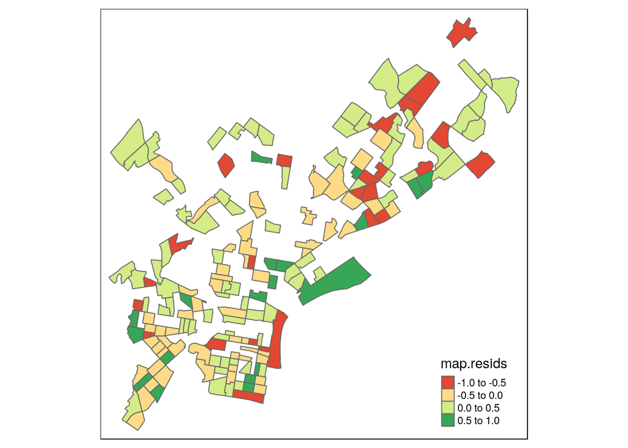

```r
resids<-residuals(model)
all.geo.spatial$map.resids <- resids
qtm(all.geo.spatial, fill = "map.resids")
```

Let’s run a geographically weighted regression.

```r
GWRbandwidth <- gwr.sel(m, data=all.geo.spatial,adapt=T)
```

```
## Adaptive q: 0.381966 CV score: 32.2307
## Adaptive q: 0.618034 CV score: 31.96479
## Adaptive q: 0.763932 CV score: 31.8761
## Adaptive q: 0.9148424 CV score: 31.82999
## Adaptive q: 0.8571998 CV score: 31.84639
## Adaptive q: 0.9473697 CV score: 31.82637
## Adaptive q: 0.9601306 CV score: 31.82466
## Adaptive q: 0.9753594 CV score: 31.81781
## Adaptive q: 0.9847713 CV score: 31.81504
## Adaptive q: 0.9905881 CV score: 31.81415
## Adaptive q: 0.9958446 CV score: 31.81362
## Adaptive q: 0.9938368 CV score: 31.81432
## Adaptive q: 0.9974318 CV score: 31.81298
## Adaptive q: 0.9984128 CV score: 31.81261
## Adaptive q: 0.999019 CV score: 31.8124
## Adaptive q: 0.9993937 CV score: 31.81227
## Adaptive q: 0.9996253 CV score: 31.81219
## Adaptive q: 0.9997684 CV score: 31.81214
## Adaptive q: 0.9998569 CV score: 31.81211
## Adaptive q: 0.9999115 CV score: 31.81209
## Adaptive q: 0.9999523 CV score: 31.81208
## Adaptive q: 0.9999523 CV score: 31.81208
```

```r
gwr.model = gwr(m, data=all.geo.spatial,
                adapt=GWRbandwidth, hatmatrix=TRUE, se.fit=TRUE)
gwr.model
```

```
## Call:
## gwr(formula = m, data = all.geo.spatial, adapt = GWRbandwidth,
##     hatmatrix = TRUE, se.fit = TRUE)
## Kernel function: gwr.Gauss
## Adaptive quantile: 0.9999523 (about 173 of 174 data points)
## Summary of GWR coefficient estimates at data points:
##                           Min.     1st Qu.      Median     3rd Qu.
## X.Intercept.        3.1667e-01  3.2177e-01  3.2808e-01  3.4049e-01
## HC02_EST_VC08_comp -1.4638e-02 -1.4403e-02 -1.4198e-02 -1.3358e-02
## HC02_EST_VC20_comp -1.6587e-02 -1.6395e-02 -1.4881e-02 -1.4463e-02
## HC02_EST_VC21_comp  3.7936e-03  3.8233e-03  3.8573e-03  4.0681e-03
## HC02_EST_VC34_educ  7.2989e-03  7.3776e-03  7.7348e-03  7.8490e-03
## HC02_EST_VC03_educ -8.7645e-05  4.2086e-06  1.3593e-04  2.3201e-04
## shortest.distance   1.3760e-05  1.4351e-05  1.5567e-05  1.6088e-05
##                           Max.  Global
## X.Intercept.        3.4811e-01  0.3196
## HC02_EST_VC08_comp -1.3148e-02 -0.0143
## HC02_EST_VC20_comp -1.4239e-02 -0.0151
## HC02_EST_VC21_comp  4.2130e-03  0.0040
## HC02_EST_VC34_educ  7.8937e-03  0.0076
## HC02_EST_VC03_educ  2.8163e-04  0.0002
## shortest.distance   1.6517e-05  0.0000
## Number of data points: 174
## Effective number of parameters (residual: 2traceS - traceS'S): 8.136735
## Effective degrees of freedom (residual: 2traceS - traceS'S): 165.8633
## Sigma (residual: 2traceS - traceS'S): 0.4203685
## Effective number of parameters (model: traceS): 7.595385
## Effective degrees of freedom (model: traceS): 166.4046
## Sigma (model: traceS): 0.4196842
## Sigma (ML): 0.410422
## AICc (GWR p. 61, eq 2.33; p. 96, eq. 4.21): 202.0666
## AIC (GWR p. 96, eq. 4.22): 191.4679
## Residual sum of squares: 29.30965
## Quasi-global R2: 0.1715484
```